# Geospatial Risk Predictions

Trevor Kapuvari

10/18/2023

## 0.1 Reading Data from Chicago

```r
policeDistricts <-
  st_read("https://data.cityofchicago.org/api/geospatial/fthy-xz3r?method=export&format=GeoJSON") %>%
  st_transform('ESRI:102271') %>%
  dplyr::select(District = dist_num)

drugArrest <-
  read.socrata("https://data.cityofchicago.org/Public-Safety/Crimes-2017/d62x-nvdr") %>%
    filter(Primary.Type == "NARCOTICS" & Description == "POSS: CANNABIS 30GMS OR LESS" | Description == "POSS: CANNABIS MORE THAN 30GMS") %>%
    mutate(x = gsub("[()]", "", Location)) %>%
    separate(x,into= c("Y","X"), sep=",") %>%
    mutate(X = as.numeric(X),Y = as.numeric(Y)) %>%
    na.omit() %>%
    st_as_sf(coords = c("X", "Y"), crs = 4326, agr = "constant")%>%
    st_transform('ESRI:102271') %>%
    distinct()


chicagoBoundary <-
  st_read("https://data.cityofchicago.org/api/geospatial/ewy2-6yfk?method=export&format=GeoJSON") %>%
  st_transform('ESRI:102271')
```

# 1 Introduction

Cannabis is a drug that has become a national debate regarding its safety, community effects, and purpose in society. The high number of cannabis arrests, despite legalization in many states, has been attributed to issues with accessibility and high taxes on recreational cannabis, which have led many consumers to turn to the black market.

This brief aims to create a risk prediction model for cannabis arrests in Chicago using 2017 as the reference year. The goal is to identify if predicting cannabis arrests shows inherent bias, and whether through data collection or law enforcement’s discretion/discrimination. The selection bias that is possible here is because it only shows where arrests were made, and not mere police encounters, possession, sale, or distribution of cannabis. Another factor regarding cannabis arrests is that drug offenses often are under-reported and suffer additional selection bias in terms of racial and geographic profiling. What is important to note is the decriminalization of cannabis “in small amounts” in Illinois one year prior, yet arrests were still occurring (source provided).

Source: https://fortune.com/2016/07/30/illinois-marijuana-decriminalized/

# 2 Outcome of Interest Points

This figure shows the locations of 2017 Chicago Cannabis possession arrests. There is noticeable spatial clustering in the west of the city and somewhat more in the southside, notably the impoverished neighborhoods of the city. This data proves an ineffectiveness of the policy and police discretion on how and when the decriminalization is enforced. These arrests were heavily enforced in the west and south side.

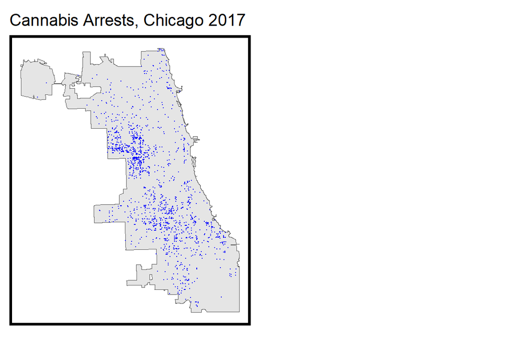

```r
grid.arrange(ncol=2,
ggplot() +
  geom_sf(data = chicagoBoundary) +
  geom_sf(data = drugArrest, colour="blue", size=0.1, show.legend = "point") +
  labs(title= "Cannabis Arrests, Chicago 2017") +
  mapTheme(title_size = 14))
```

# 3 Fishnet Grid of Cannabis Arrests

```r
fishnet <-
  st_make_grid(chicagoBoundary,
               cellsize = 500,
               square = TRUE) %>%
  .[chicagoBoundary] %>%            # fast way to select intersecting polygons
  st_sf() %>%
  mutate(uniqueID = 1:n())
```

### 3.0.1 Aggregate points to the fishnet

Cannabis arrests are displayed through a fishnet grid, which breaks the Chicago boundary into square plots that accounts for geographies and the density of values. The fishnet displays a concentration of arrests for cannabis possession because of the dedicated resources in a specific area. While the previous map showed cannabis arrests occurring all over the city, the areas had a low frequency of cannabis arrests and could not be described the same way as shown here. Here, the map displays the frequency of cannabis arrests.

We prefer to use fishnet grid data for these kind of visualizations as it allows for squared division of space.

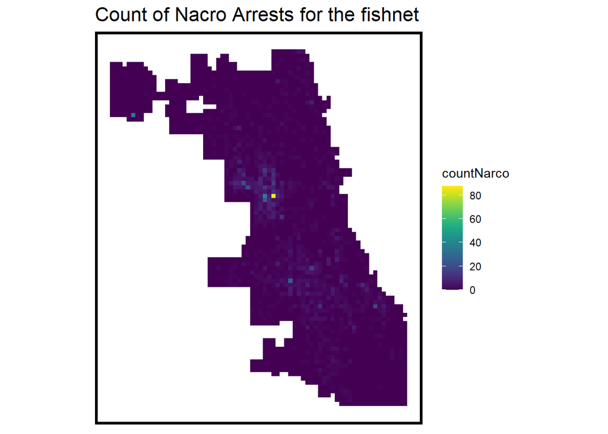

```r
crime_net <-
  dplyr::select(drugArrest) %>%
  mutate(countNarco = 1) %>%
  aggregate(., fishnet, sum) %>%
  mutate(countNarco = replace_na(countNarco, 0),
         uniqueID = 1:n(),
         cvID = sample(round(nrow(fishnet) / 24),
                       size=nrow(fishnet), replace = TRUE))

ggplot() +
  geom_sf(data = crime_net, aes(fill = countNarco), color = NA) +
  scale_fill_viridis() +
  labs(title = "Count of Nacro Arrests for the fishnet") +
  mapTheme()
```

# 4 A small multiple map of your risk factors in the fishnet (counts, distance and/or other feature engineering approaches).

```r
registeredMurals <-
  read.socrata("https://data.cityofchicago.org/Historic-Preservation/Mural-Registry/we8h-apcf") %>%
    dplyr::select(Y = latitude, X = longitude) %>%
    na.omit() %>%
    st_as_sf(coords = c("X", "Y"), crs = 4326, agr = "constant") %>%
    st_transform(st_crs(fishnet)) %>%
    mutate(Legend = "Registered_Murals") %>%
    mutate(uniqueID = 1:n(),) %>%
    filter(uniqueID != 439) %>%
    filter(uniqueID != 440) %>%
    filter(uniqueID != 441) %>%
    filter(uniqueID != 442) %>%
    filter(uniqueID != 443) %>%
    group_by(Legend)

registeredMurals <- registeredMurals %>%
  dplyr::select(geometry, Legend)


parks <-
  st_read("https://github.com/TrevorKap/MUSA5000/raw/main/lowkeyPPA/Geospatial/Parks%20-%20Chicago%20Park%20District%20Facilities%20(current).geojson") %>%
  st_transform(st_crs(fishnet))
parks <- parks %>%
  group_by(park) %>%
  rename(Legend = park) %>%
  summarise()

parks$Legend = "park"


neighborhoods <-
  st_read("https://raw.githubusercontent.com/blackmad/neighborhoods/master/chicago.geojson") %>%
  st_transform(st_crs(fishnet))

abandoned_buildings <-
  read.socrata("https://data.cityofchicago.org/Service-Requests/311-Service-Requests-Vacant-and-Abandoned-Building/7nii-7srd") %>%
  mutate(year = substr(date_service_request_was_received,1,4)) %>%  filter(year == "2017") %>%
  dplyr::select(Y = latitude, X = longitude) %>%
  na.omit() %>%
  st_as_sf(coords = c("X", "Y"), crs = 4326, agr = "constant") %>%
  st_transform(st_crs(fishnet)) %>%
  mutate(Legend = "Abandoned_Buildings")


streetLightsOut <-
  read.socrata("https://data.cityofchicago.org/Service-Requests/311-Service-Requests-Street-Lights-All-Out/zuxi-7xem") %>%
    mutate(year = substr(creation_date,1,4)) %>% filter(year == "2017") %>%
    dplyr::select(Y = latitude, X = longitude) %>%
    na.omit() %>%
    st_as_sf(coords = c("X", "Y"), crs = 4326, agr = "constant") %>%
    st_transform(st_crs(fishnet)) %>%
    mutate(Legend = "Street_Lights_Out")

sanitation <-
  read.socrata("https://data.cityofchicago.org/Service-Requests/311-Service-Requests-Sanitation-Code-Complaints-Hi/me59-5fac") %>%
    mutate(year = substr(creation_date,1,4)) %>% filter(year == "2017") %>%
    dplyr::select(Y = latitude, X = longitude) %>%
    na.omit() %>%
    st_as_sf(coords = c("X", "Y"), crs = 4326, agr = "constant") %>%
    st_transform(st_crs(fishnet)) %>%
    mutate(Legend = "Sanitation")

tracts17 <-
  get_acs(geography = "tract", variables = c("B01001_001E","B01001A_001E"),
          year = 2017, state=17, county=031, geometry=T) %>%
  st_transform('ESRI:102271')  %>%
  dplyr::select(variable, estimate, GEOID) %>%
  spread(variable, estimate) %>%
  rename(TotalPop = B01001_001,
         NumberWhites = B01001A_001) %>%
  mutate(percentWhite = NumberWhites / TotalPop,
         raceContext = ifelse(percentWhite > .5, "Majority_White", "Majority_Non_White"))
```

```r
vars_net <-
  rbind(registeredMurals, parks, abandoned_buildings, streetLightsOut, sanitation) %>%
  st_join(fishnet, join=st_within) %>%
  st_drop_geometry() %>%
  group_by(uniqueID, Legend) %>%
  summarize(count = n()) %>%
  left_join(fishnet, ., by = "uniqueID") %>%
  spread(Legend, count, fill=0) %>%
  dplyr::select(-`<NA>`) %>%
  ungroup()
```

## 4.1 Nearest Neighbor & Count

Nearest Neighbor is a way of finding similar data points to new data points that are nearby. This technique in machine learning helps conclude spatial autocorrelation, determining if clusters are valued together.

For the k-folds, this validation technique evaluates the performance of the machine learning, it divides the training set into “k” number of times.

```r
st_c    <- st_coordinates
st_coid <- st_centroid

vars_net <- vars_net %>%
    mutate(Registered_Murals.nn = nn_function(st_c(st_coid(vars_net)),
                                           st_c(registeredMurals),
                                           k = 8))

vars_net <- vars_net %>%
    mutate(abandoned_buildings.nn = nn_function(st_c(st_coid(vars_net)),
                                           st_c(abandoned_buildings),
                                           k = 8))
```

```r
vars_net.long.nn <-
  dplyr::select(vars_net, ends_with(".nn")) %>%
    gather(Variable, value, -geometry)
```

```r
final_net <-
  left_join(crime_net, st_drop_geometry(vars_net), by="uniqueID")
```

```r
final_net <-
  st_centroid(final_net) %>%
    st_join(dplyr::select(neighborhoods, name), by = "uniqueID") %>%
    st_join(dplyr::select(policeDistricts, District), by = "uniqueID") %>%
      st_drop_geometry() %>%
      left_join(dplyr::select(final_net, geometry, uniqueID)) %>%
      st_sf() %>%
  na.omit()
```

The maps depict the density of our independent variables throughout Chicago. Each of these are used in the model to predict if they increase or decrease the likelihood of cannabis arrests, and will eventually predict the amount of arrests in each square based on that information. Two factored considered in terms of geography is the “count”, which measures the frequency of the independent variable present in that cell, and the nearest neighbor. The nearest neighbor measures how close an independent variable is from another one of itself (ex, how far murals are from one another). This can also be used in predictions because it factors whether a “stand-alone” of an independent variable creates a change or if there needs to be multiple, concentrated in that area.

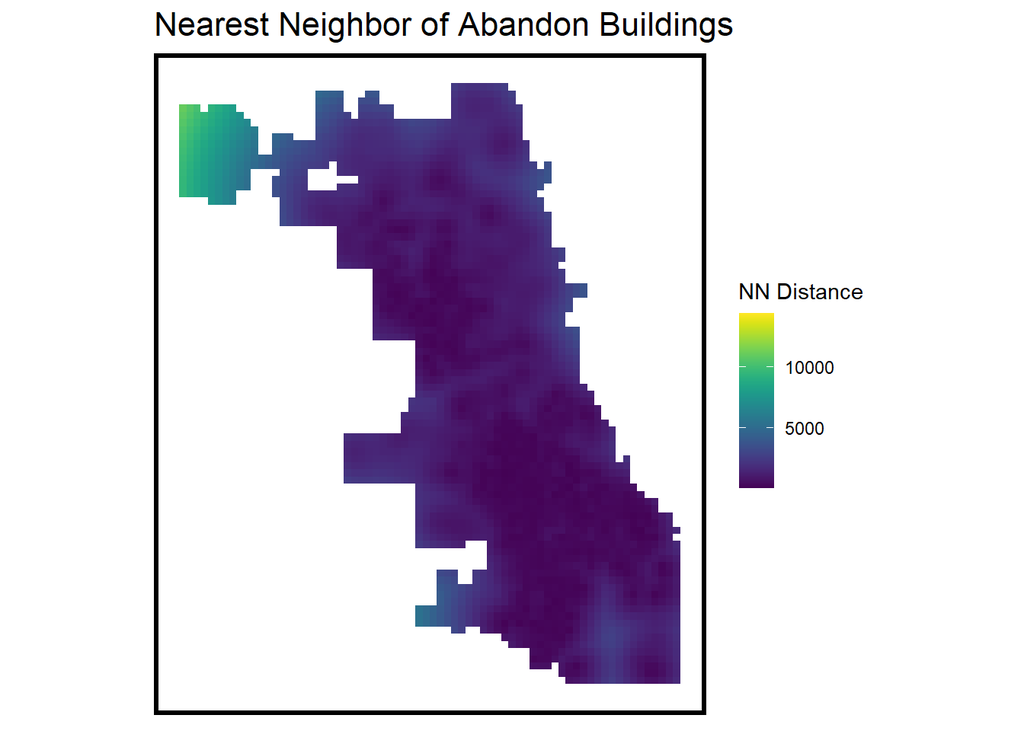

```r
ggplot() +
      geom_sf(data = vars_net.long.nn, aes(fill=value), colour=NA) +
      scale_fill_viridis(name="NN Distance") +
      labs(title="Nearest Neighbor of Abandon Buildings") +
      mapTheme()
```

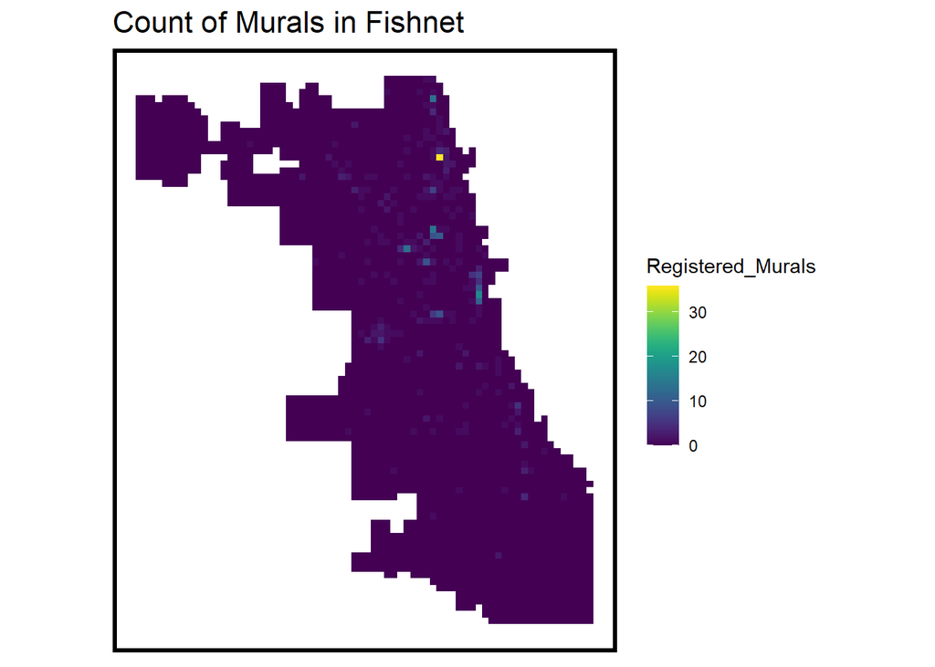

```r
ggplot() +
  geom_sf(data = vars_net, aes(fill=Registered_Murals), colour=NA) +
  scale_fill_viridis() +
  labs(title = "Count of Murals in Fishnet") +
  mapTheme()
```

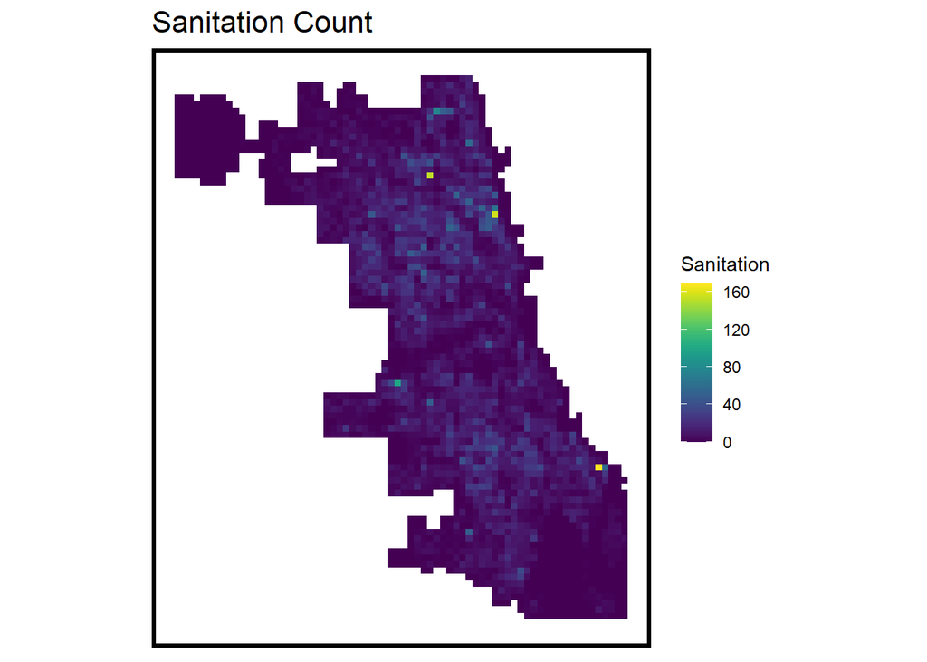

```r
ggplot() +
  geom_sf(data = vars_net, aes(fill=Sanitation), colour=NA) +
  scale_fill_viridis() +
  labs(title = "Sanitation Count") +
  mapTheme()
```

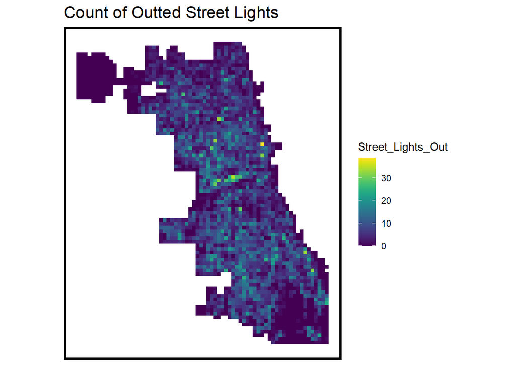

```r
ggplot() +
  geom_sf(data = vars_net, aes(fill=Street_Lights_Out), colour=NA) +
  scale_fill_viridis() +
  labs(title = "Count of Outted Street Lights") +
  mapTheme()
```

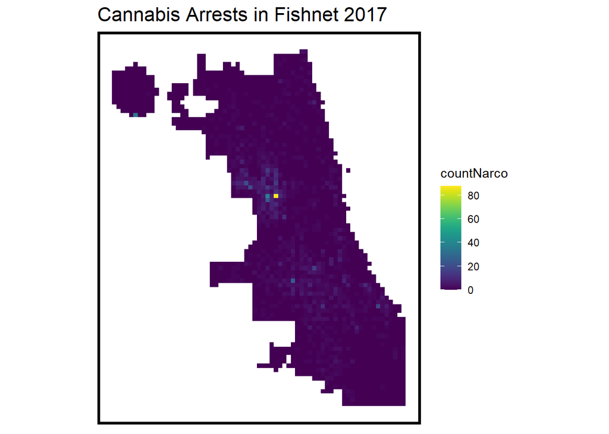

```r
ggplot() +
      geom_sf(data = final_net, aes(fill=countNarco), colour=NA) +
      scale_fill_viridis() +
      labs(title="Cannabis Arrests in Fishnet 2017") +
      mapTheme()
```

# 5 Local Moran’s I

Local Moran’s I measures spatial autocorrelation for each box on the fishnet grid. Having a Moran’s I on the fishnet specifically helps identify hotpots of predicted cannabis arrests.

```r
final_net.nb <- poly2nb(as_Spatial(final_net), queen=TRUE)

final_net.weights <- nb2listw(final_net.nb, style="W", zero.policy=TRUE)
```

```r
local_morans <- localmoran(final_net$Registered_Murals, final_net.weights, zero.policy=TRUE) %>%
  as.data.frame()


final_net.localMorans <-
  cbind(local_morans, as.data.frame(final_net)) %>%
  st_sf() %>%
  dplyr::select(Registered_Murals_Count = Registered_Murals,
                Local_Morans_I = Ii,
                P_Value = `Pr(z != E(Ii))`) %>%
  mutate(Significant_Hotspots = ifelse(P_Value <= 0.001, 1, 0)) %>%
  gather(Variable, Value, -geometry)
```

## 5.1 Plotting local Moran’s I results

The first maps displays the raw number of murals in each cell. Most areas of Chicago do not have any murals to begin with. The second shows the Moran’s I of the Murals. Just as with the raw number itself, these are almost identical. Areas that have murals will often have multiple while the vast majority have nothing.

The fourth map shows the hotspots, where the murals are most concentrated. There is a clear difference between where the murals are concentrated.

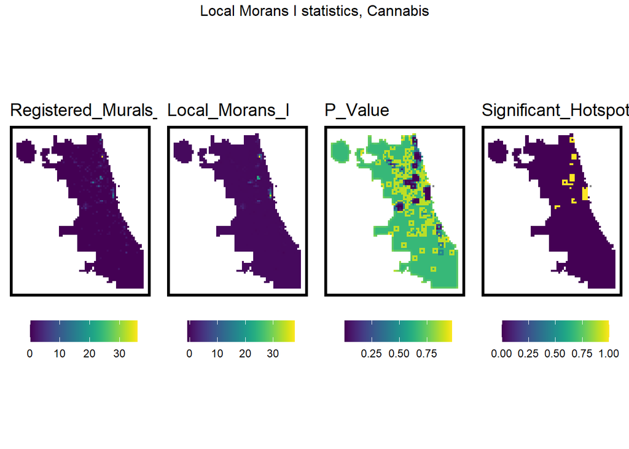

```r
vars <- unique(final_net.localMorans$Variable)
varList <- list()

for(i in vars){
  varList[[i]] <-
    ggplot() +
      geom_sf(data = filter(final_net.localMorans, Variable == i),
              aes(fill = Value), colour=NA) +
      scale_fill_viridis(name="") +
      labs(title=i) +
      mapTheme(title_size = 14) + theme(legend.position="bottom")}

do.call(grid.arrange,c(varList, ncol = 4, top = "Local Morans I statistics, Cannabis"))
```

```r
final_net <- final_net %>%
  mutate(Mural.isSig =
           ifelse(local_morans[,5] <= 0.001, 1, 0)) %>%
  mutate(Mural.isSig.dist =
           nn_function(st_c(st_coid(final_net)),
                       st_c(st_coid(filter(final_net,
                                           Mural.isSig == 1))), k = 1))
```

# 6 Multiple Scatterplot with Correlation

As can see from the scatterplots, Abandoned Buildings, Sanitation, and Streets Lights Out provide a positive correlation and correlate with stricter cannabis enforcement.

We see hardly any difference from murals and parks, one likelihood can be because of insufficient amounts of data (not a lot of parks or murals to begin with).

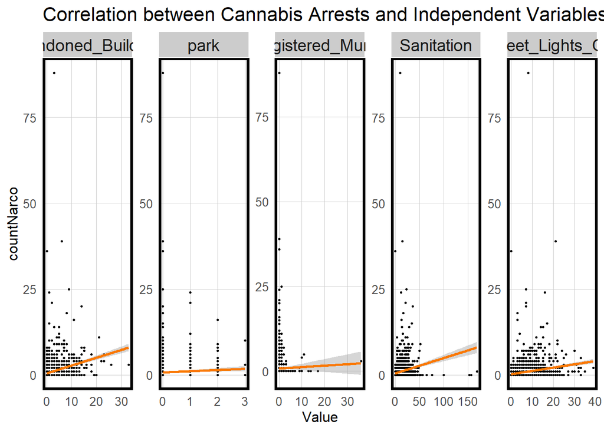

```r
final_net_nongeom <- final_net %>% st_drop_geometry()

final_net_nongeom %>%
  dplyr::select(countNarco, Registered_Murals, park, Abandoned_Buildings, Sanitation, Street_Lights_Out) %>%
  gather(Variable, Value, -countNarco) %>%
  ggplot(aes(Value, countNarco)) +
     geom_point(size = .5) + geom_smooth(method = "lm", colour = "#FA7800") +
     facet_wrap(~Variable, nrow = 1, scales = "free") +
     labs(title = "Correlation between Cannabis Arrests and Independent Variables") +
     plotTheme()
```

# 7 Histogram of Dependent Varaible (Cannabis Arrests)

The histogram shows that majority of areas do not have many cannabis arrests, hence the large 0 value. Yet the right skewedness proves there are only a few areas that have significantly more cannabis arrests, showing a concentration in enforcement. As shown from the first map, arrests occurred all over the city, yet the biggest cluster observed and now detected have a strong density that outweights the rest of the city.

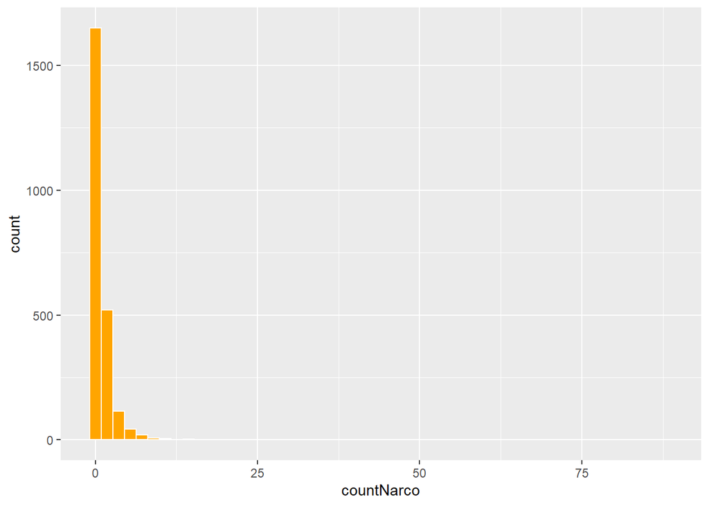

```r
  ggplot(final_net, aes(x=countNarco)) +
  geom_histogram(color='white',fill="orange", bins=50)+
  scale_x_continuous()+
  scale_y_continuous()
```